# Tech 4. Main Analyses

## Figure 3. Variance Reduction by Level

```r
#reorder categories to match the order presented in the text
fig3 <- fig2
fig3[1:5,] <- fig2[16:20,]
fig3[6:10,] <- fig2[6:10,]
fig3[11:15,] <- fig2[1:5,]
fig3[16:20,] <- fig2[11:15,]
```

```r
fig3$level <- factor(fig3$level, levels = c(" ","  ","   ","    ","Subjective conclusion\nBetween-team deviance","Avg. Marginal Effects\nWithin-team variance","Avg. Marginal Effects\nBetween-team variance","Avg. Marginal Effects\nTotal variance","     "))

fig3_labs <- c(" ","  ","   ","     ","<span style = \"font-size: 14px\">**Subjective Conclusions**</span><br>Between-team deviance","<span style = \"font-size: 14px\">**Avg. Marginal Effects**</span><br>Within-team variance","<span style = \"font-size: 14px\">**Avg. Marginal Effects**</span><br>Between-team variance","<span style = \"font-size: 14px\">**Avg. Marginal Effects**</span><br>Total variance"," ")
```

```r
agg_png(filename= here::here("results/Fig3.png"), res = 144, width = 1100, height = 800)
ggplot(fig3, aes(x = level, y = percent, fill = type)) +
  geom_bar(stat = "identity") +
  coord_flip() +
  labs(x = "", y = "", fill = "Percent\nexplained by") +
  md_theme_classic() +
  labs(title = "<span style = \"font-size: 18px\">**Factors Explaining Variance in Results**</span>") +
  scale_x_discrete(labels = fig3_labs, drop = FALSE) +
  scale_y_reverse() +
  geom_rect(aes(xmin = 2, xmax = 4.1, ymin = 0.005, ymax = 0.24), color = "#E6AB02", size = 1.5, fill = "transparent") +
  geom_rect(aes(xmin = 2, xmax = 4.1, ymin = 0.26, ymax = 0.49), color = "#7570B3", size = 1.5, fill = "transparent") +
  geom_rect(aes(xmin = 2, xmax = 4.1, ymin = 0.51, ymax = 0.74), color = "#1B9E77", size = 1.5, fill = "transparent") +
  geom_rect(aes(xmin = 2, xmax = 4.1, ymin = 0.76, ymax = 0.995), color = "#666666", size = 1.5, fill = "transparent") +
  annotate("text", x = 3.7, y = 0.124, label = "UNEXPLAINED\nVARIANCE", color = "black", size = 3) +
  annotate("text", x = 3.7, y = 0.375, label = "RESEARCHER\nCHARACTERISTICS", color = "black",  size = 3) +
  annotate("text", x = 3.7, y = 0.624, label = "RESEARCHER\nDECISIONS", color = "black",  size = 3) +
  annotate("text", x = 3.7, y = 0.876, label = "ASSIGNED\nCONDITIONS", color = "black",  size = 3) +
  annotate("text", x = 2.3, y = 0.228, label = "Idiosyncratic remaining\nvariance associated\nwith each team's\nresearch design", size = 2.5, color = "grey12", hjust = 0, vjust = 0) +
  annotate("text", x = 2.3, y = 0.48, label = "- Method expertise\n- Topic expertise\n- Prior attitudes\n- Prior beliefs", size = 2.5, color = "grey12", hjust = 0, vjust = 0) +
  annotate("text", x = 2.3, y = 0.730, label = "- Measurement\n- Sample selection\n- Model specification\n- Model ranking", size = 2.5, color = "grey12", hjust = 0, vjust = 0) +
  annotate("text", x = 2.77, y = 0.988, label = "- Materials provided\n- Pre-analysis tasks", size = 2.5, color = "grey12", hjust = 0, vjust = 0) +
  annotate("text", x = 8.8, y = 1, hjust = 0, label = "0%", size = 3.5) +
  annotate("text", x = 8.8, y = 0.75,  label = "25%", size = 3.5) +
  annotate("text", x = 8.8, y = 0.5,  label = "50%", size = 3.5) +
  annotate("text", x = 8.8, y = 0.25,  label = "75%", size = 3.5) +
  annotate("text", x = 8.8, y = 0, hjust = 1, label = "100%", size = 3.5) +
  annotate("text", x = 5, y = 0.67,  label = "% POSITIVE\nTEST RESULTS", size = 2.5, color = "grey20") +
  annotate("text", x = 6.8, y = 0.1, label = "82.4%", fontface= 2) +
  annotate("text", x = 5.8, y = 0.1, label = "96.8%", fontface= 2) +
  annotate("text", x = 7.8, y = 0.1, label = "95.2%", fontface= 2) +
  annotate("text", x = 4.8, y = 0.143, label = "80.1 / 52.4%", fontface= 2) +
  annotate("text", x = 4.8, y = 0.35, label = "unexplained =", fontface= 3, size = 3) +
  annotate("segment", x = 4.15, y = 0.123, xend = 4.55, yend = 0.45, color = "#E6AB02") +
  annotate("segment",x = 4.15, y = 0.376, xend = 4.55, yend = 0.85, color = "#7570B3") +
  annotate("segment",x = 4.15, y = 0.626, xend = 4.55, yend = 0.945, color = "#1B9E77") +
  annotate("segment",x = 4.15, y = 0.876, xend = 4.55, yend = 0.99, color = "#666666") +
  scale_fill_manual(values = c("Objective conditions" = "#666666",
                                "Research design" = "#1B9E77",
                                "Researcher characteristics" = "#7570B3",
                                "Results" = "lightpink1",
                                "Unexplained variance" = "#E6AB02")) +
  theme(axis.line = element_blank(),
        axis.text.x = element_blank(),
        axis.ticks = element_blank(),
        legend.position = "none")
dev.off()
```

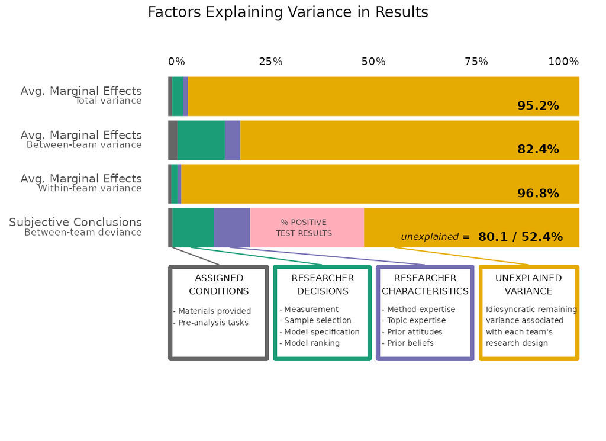

```r
knitr::include_graphics(here::here("results/Fig3.png"))
```

### Save output for multiverse analysis

```r
write.csv(cri_ml, file = here::here("results/cri_ml.csv"))
write.csv(cri_team, file = here::here("results/cri_team.csv"))
```

### Researcher Characteristics

Additional research question: Do researcher characteristics explain model specifications?

Not used in our main results, but left here for future research/researchers. The short answer is yes they do, and this is interesting!

For this we use the data `crispectest`, worked up in `03_CRI_Spec_Analysis.Rmd`. For simplicity we use a multinomial model and calculate deviance reduction using dummies.

iv_type IV_None degree (1 = other, 2 = methods focus, 3 = soc, 4 = polsci, 5 = psych) software mator twowayfe SURVEY_WAVES COUNTRIES

```r
rchars <- "belief_ipredm + pro_immigrantm + topic_ipredm + stats_ipred + factor(u_teamid)"

#set reference levels, add degree types
crispectest$iv_type <- relevel(factor(crispectest$iv_type, levels = c("Stock","Flow","ChangeFlow")), ref = "Stock")
crispectest$software <- relevel(factor(crispectest$software), ref = "Stata")
crispectest$degree <- car::recode(crispectest$degree, "1 = 'Other';2 = 'Methods_focus'; 3 = 'Sociology'; 4 = 'Poli_Sci'; 5 = 'Psych'")

crispectest$degree <- relevel(factor(crispectest$degree), ref = "Sociology")

# Test strategy
m100 <- multinom(iv_type ~ 1, data = crispectest)
m101 <- multinom(iv_type ~ factor(u_teamid), data = crispectest)
m102 <- multinom(paste0("iv_type ~", rchars), data = crispectest)
m103 <- multinom(paste0("iv_type ~", rchars, "+ degree + software"), data = crispectest)
#
tab_model(m103, digits = 3, p.style = "stars", rm.terms = c("factor(u_teamid)10","factor(u_teamid)101","factor(u_teamid)104","factor(u_teamid)106","factor(u_teamid)12","factor(u_teamid)13","factor(u_teamid)16","factor(u_teamid)17","factor(u_teamid)18","factor(u_teamid)19","factor(u_teamid)20","factor(u_teamid)21","factor(u_teamid)23","factor(u_teamid)22","factor(u_teamid)26","factor(u_teamid)27","factor(u_teamid)28","factor(u_teamid)29","factor(u_teamid)3","factor(u_teamid)30","factor(u_teamid)31","factor(u_teamid)32","factor(u_teamid)33","factor(u_teamid)34","factor(u_teamid)35","factor(u_teamid)36","factor(u_teamid)37","factor(u_teamid)38","factor(u_teamid)39","factor(u_teamid)40","factor(u_teamid)41","factor(u_teamid)42","factor(u_teamid)43","factor(u_teamid)44","factor(u_teamid)45","factor(u_teamid)46","factor(u_teamid)47","factor(u_teamid)48","factor(u_teamid)49","factor(u_teamid)5","factor(u_teamid)52","factor(u_teamid)53","factor(u_teamid)54","factor(u_teamid)55","factor(u_teamid)56","factor(u_teamid)57","factor(u_teamid)58","factor(u_teamid)59","factor(u_teamid)6","factor(u_teamid)60","factor(u_teamid)61","factor(u_teamid)62","factor(u_teamid)63","factor(u_teamid)64","factor(u_teamid)65","factor(u_teamid)66","factor(u_teamid)67","factor(u_teamid)68","factor(u_teamid)69","factor(u_teamid)70","factor(u_teamid)71","factor(u_teamid)7","factor(u_teamid)72","factor(u_teamid)73","factor(u_teamid)75","factor(u_teamid)77","factor(u_teamid)8","factor(u_teamid)82","factor(u_teamid)83","factor(u_teamid)84","factor(u_teamid)86","factor(u_teamid)87","factor(u_teamid)93","factor(u_teamid)94","factor(u_teamid)95","factor(u_teamid)96","factor(u_teamid)97","factor(u_teamid)98"), show.ci = F, show.dev = T, show.loglik = T, transform = NULL, file = here::here("results/reg103.htm"))
```

iv_type

Predictors

Log-Odds

Response

(Intercept)

-2.846

Flow

belief ipredm

0.293

Flow

pro immigrantm

-0.594

Flow

topic ipredm

2.805 ***

Flow

stats ipred

-5.689 *

Flow

degree [Methods_focus]

-1.867

Flow

degree [Other]

-1.601

Flow

degree [Poli_Sci]

3.985 *

Flow

degree [Psych]

3.652

Flow

software [MLwiN]

3.623 *

Flow

software [Mplus]

0.749

Flow

software [R]

-1.729

Flow

software [SPSS]

2.016

Flow

(Intercept)

-14.965 ***

ChangeFlow

belief ipredm

-0.883

ChangeFlow

pro immigrantm

-0.034

ChangeFlow

topic ipredm

0.621

ChangeFlow

stats ipred

-3.987

ChangeFlow

degree [Methods_focus]

-4.115 *

ChangeFlow

degree [Other]

-4.917 **

ChangeFlow

degree [Poli_Sci]

-0.561

ChangeFlow

degree [Psych]

-3.147

ChangeFlow

software [MLwiN]

4.713

ChangeFlow

software [Mplus]

2.672

ChangeFlow

software [R]

-2.734

ChangeFlow

software [SPSS]

-0.049

ChangeFlow

Observations

1240

R<sup>2</sup> / R<sup>2</sup> adjusted

0.177 / 0.176

Deviance

1687.765

log-Likelihood

-843.883

- p<0.05 ** p<0.01 *** p<0.001

## Colophon

This file is part of https://github.com/nbreznau/CRI, the reproduction materials for [*Observing Many Researchers using the Same Data and Hypothesis Reveals a Hidden Universe of Uncertainty*](https://doi.org/10.31222/osf.io/cd5j9).